# Case Study: Movies And Books Recommendation System

[figure not shown]

# Introduction

During the last few decades, with the rise of Youtube, Amazon, Netflix and many other such web services, recommender systems have taken more and more place in our lives. From e-commerce (suggest to buyers articles that could interest them) to online advertisement (suggest to users the right contents, matching their preferences), recommender systems are today unavoidable in our daily online journeys.

In a very general way, recommender systems are algorithms aimed at suggesting relevant items to users (items being movies to watch, text to read, products to buy or anything else depending on industries).

Recommender systems are really critical in some industries as they can generate a huge amount of income when they are efficient or also be a way to stand out significantly from competitors. As a proof of the importance of recommender systems, a few years ago, Netflix organised a challenges (the “Netflix prize”) where the goal was to produce a recommender system that performs better than its own algorithm with a prize of 1 million dollars to win.

In this project, different types of recommender systems will be implemented to make a good recommendation for the users in movies and books. For each of them, it can be observe how they work, describe their theoretical aspect.

**Dataset:**

- [Movies Dataset](https://www.kaggle.com/tmdb/tmdb-movie-metadata)
- [Books Dataset](http://www2.informatik.uni-freiburg.de/~cziegler/BX/)

# Review

[figure not shown]

# Movie Recommendation System

## Weighted Hybrid Technique

[figure not shown]

### Import Libraries And Data

```python
# Import libraries
import pandas as pd
import numpy as np
```

```python
# Import datasets
movies_df = pd.read_csv("tmdb_5000_movies.csv")
credits = pd.read_csv("tmdb_5000_credits.csv")
```

### Data Exploration

```python
# Check movies data
movies_df.head()
```

|  | budget | genres | homepage | id | keywords | original_language | original_title | overview | popularity | production_companies | production_countries | release_date | revenue | runtime | spoken_languages | status | tagline | title | vote_average | vote_count |
| --- | --- | --- | --- | --- | --- | --- | --- | --- | --- | --- | --- | --- | --- | --- | --- | --- | --- | --- | --- | --- |
| 0 | 237000000 | [{"id": 28, "name": "Action"}, {"id": 12, "nam... | http://www.avatarmovie.com/ | 19995 | [{"id": 1463, "name": "culture clash"}, {"id":... | en | Avatar | In the 22nd century, a paraplegic Marine is di... | 150.438 | [{"name": "Ingenious Film Partners", "id": 289... | [{"iso_3166_1": "US", "name": "United States o... | 2009-12-10 | 2787965087 | 162.000 | [{"iso_639_1": "en", "name": "English"}, {"iso... | Released | Enter the World of Pandora. | Avatar | 7.200 | 11800 |
| 1 | 300000000 | [{"id": 12, "name": "Adventure"}, {"id": 14, "... | http://disney.go.com/disneypictures/pirates/ | 285 | [{"id": 270, "name": "ocean"}, {"id": 726, "na... | en | Pirates of the Caribbean: At World's End | Captain Barbossa, long believed to be dead, ha... | 139.083 | [{"name": "Walt Disney Pictures", "id": 2}, {"... | [{"iso_3166_1": "US", "name": "United States o... | 2007-05-19 | 961000000 | 169.000 | [{"iso_639_1": "en", "name": "English"}] | Released | At the end of the world, the adventure begins. | Pirates of the Caribbean: At World's End | 6.900 | 4500 |
| 2 | 245000000 | [{"id": 28, "name": "Action"}, {"id": 12, "nam... | http://www.sonypictures.com/movies/spectre/ | 206647 | [{"id": 470, "name": "spy"}, {"id": 818, "name... | en | Spectre | A cryptic message from Bond’s past sends him o... | 107.377 | [{"name": "Columbia Pictures", "id": 5}, {"nam... | [{"iso_3166_1": "GB", "name": "United Kingdom"... | 2015-10-26 | 880674609 | 148.000 | [{"iso_639_1": "fr", "name": "Fran\u00e7ais"},... | Released | A Plan No One Escapes | Spectre | 6.300 | 4466 |
| 3 | 250000000 | [{"id": 28, "name": "Action"}, {"id": 80, "nam... | http://www.thedarkknightrises.com/ | 49026 | [{"id": 849, "name": "dc comics"}, {"id": 853,... | en | The Dark Knight Rises | Following the death of District Attorney Harve... | 112.313 | [{"name": "Legendary Pictures", "id": 923}, {"... | [{"iso_3166_1": "US", "name": "United States o... | 2012-07-16 | 1084939099 | 165.000 | [{"iso_639_1": "en", "name": "English"}] | Released | The Legend Ends | The Dark Knight Rises | 7.600 | 9106 |
| 4 | 260000000 | [{"id": 28, "name": "Action"}, {"id": 12, "nam... | http://movies.disney.com/john-carter | 49529 | [{"id": 818, "name": "based on novel"}, {"id":... | en | John Carter | John Carter is a war-weary, former military ca... | 43.927 | [{"name": "Walt Disney Pictures", "id": 2}] | [{"iso_3166_1": "US", "name": "United States o... | 2012-03-07 | 284139100 | 132.000 | [{"iso_639_1": "en", "name": "English"}] | Released | Lost in our world, found in another. | John Carter | 6.100 | 2124 |

```python
# Check credits data
credits.head()
```

|  | movie_id | title | cast | crew |
| --- | --- | --- | --- | --- |
| 0 | 19995 | Avatar | [{"cast_id": 242, "character": "Jake Sully", "... | [{"credit_id": "52fe48009251416c750aca23", "de... |
| 1 | 285 | Pirates of the Caribbean: At World's End | [{"cast_id": 4, "character": "Captain Jack Spa... | [{"credit_id": "52fe4232c3a36847f800b579", "de... |
| 2 | 206647 | Spectre | [{"cast_id": 1, "character": "James Bond", "cr... | [{"credit_id": "54805967c3a36829b5002c41", "de... |
| 3 | 49026 | The Dark Knight Rises | [{"cast_id": 2, "character": "Bruce Wayne / Ba... | [{"credit_id": "52fe4781c3a36847f81398c3", "de... |
| 4 | 49529 | John Carter | [{"cast_id": 5, "character": "John Carter", "c... | [{"credit_id": "52fe479ac3a36847f813eaa3", "de... |

```python
# Check datasets dimension
print("Credits:", credits.shape)
print("Movies:", movies_df.shape)
```

```
Credits: (4803, 4)
Movies: (4803, 20)
```

### Data Preprocessing

```python
# Rename column
credits_column_renamed = credits.rename(index = str, columns = {"movie_id": "id"})

# Merge column data
movies_df_merge = movies_df.merge(credits_column_renamed, on = 'id')

# Check data
movies_df_merge.head()
```

|  | budget | genres | homepage | id | keywords | original_language | original_title | overview | popularity | production_companies | ... | runtime | spoken_languages | status | tagline | title_x | vote_average | vote_count | title_y | cast | crew |
| --- | --- | --- | --- | --- | --- | --- | --- | --- | --- | --- | --- | --- | --- | --- | --- | --- | --- | --- | --- | --- | --- |
| 0 | 237000000 | [{"id": 28, "name": "Action"}, {"id": 12, "nam... | http://www.avatarmovie.com/ | 19995 | [{"id": 1463, "name": "culture clash"}, {"id":... | en | Avatar | In the 22nd century, a paraplegic Marine is di... | 150.438 | [{"name": "Ingenious Film Partners", "id": 289... | ... | 162.000 | [{"iso_639_1": "en", "name": "English"}, {"iso... | Released | Enter the World of Pandora. | Avatar | 7.200 | 11800 | Avatar | [{"cast_id": 242, "character": "Jake Sully", "... | [{"credit_id": "52fe48009251416c750aca23", "de... |
| 1 | 300000000 | [{"id": 12, "name": "Adventure"}, {"id": 14, "... | http://disney.go.com/disneypictures/pirates/ | 285 | [{"id": 270, "name": "ocean"}, {"id": 726, "na... | en | Pirates of the Caribbean: At World's End | Captain Barbossa, long believed to be dead, ha... | 139.083 | [{"name": "Walt Disney Pictures", "id": 2}, {"... | ... | 169.000 | [{"iso_639_1": "en", "name": "English"}] | Released | At the end of the world, the adventure begins. | Pirates of the Caribbean: At World's End | 6.900 | 4500 | Pirates of the Caribbean: At World's End | [{"cast_id": 4, "character": "Captain Jack Spa... | [{"credit_id": "52fe4232c3a36847f800b579", "de... |
| 2 | 245000000 | [{"id": 28, "name": "Action"}, {"id": 12, "nam... | http://www.sonypictures.com/movies/spectre/ | 206647 | [{"id": 470, "name": "spy"}, {"id": 818, "name... | en | Spectre | A cryptic message from Bond’s past sends him o... | 107.377 | [{"name": "Columbia Pictures", "id": 5}, {"nam... | ... | 148.000 | [{"iso_639_1": "fr", "name": "Fran\u00e7ais"},... | Released | A Plan No One Escapes | Spectre | 6.300 | 4466 | Spectre | [{"cast_id": 1, "character": "James Bond", "cr... | [{"credit_id": "54805967c3a36829b5002c41", "de... |
| 3 | 250000000 | [{"id": 28, "name": "Action"}, {"id": 80, "nam... | http://www.thedarkknightrises.com/ | 49026 | [{"id": 849, "name": "dc comics"}, {"id": 853,... | en | The Dark Knight Rises | Following the death of District Attorney Harve... | 112.313 | [{"name": "Legendary Pictures", "id": 923}, {"... | ... | 165.000 | [{"iso_639_1": "en", "name": "English"}] | Released | The Legend Ends | The Dark Knight Rises | 7.600 | 9106 | The Dark Knight Rises | [{"cast_id": 2, "character": "Bruce Wayne / Ba... | [{"credit_id": "52fe4781c3a36847f81398c3", "de... |
| 4 | 260000000 | [{"id": 28, "name": "Action"}, {"id": 12, "nam... | http://movies.disney.com/john-carter | 49529 | [{"id": 818, "name": "based on novel"}, {"id":... | en | John Carter | John Carter is a war-weary, former military ca... | 43.927 | [{"name": "Walt Disney Pictures", "id": 2}] | ... | 132.000 | [{"iso_639_1": "en", "name": "English"}] | Released | Lost in our world, found in another. | John Carter | 6.100 | 2124 | John Carter | [{"cast_id": 5, "character": "John Carter", "c... | [{"credit_id": "52fe479ac3a36847f813eaa3", "de... |

5 rows × 23 columns

```python
# Drop unnecessary columns
movies_cleaned_df = movies_df_merge.drop(columns = ['homepage', 'title_x', 'title_y', 'status','production_countries'])

# Check data
movies_cleaned_df.head()
```

|  | budget | genres | id | keywords | original_language | original_title | overview | popularity | production_companies | release_date | revenue | runtime | spoken_languages | tagline | vote_average | vote_count | cast | crew |
| --- | --- | --- | --- | --- | --- | --- | --- | --- | --- | --- | --- | --- | --- | --- | --- | --- | --- | --- |
| 0 | 237000000 | [{"id": 28, "name": "Action"}, {"id": 12, "nam... | 19995 | [{"id": 1463, "name": "culture clash"}, {"id":... | en | Avatar | In the 22nd century, a paraplegic Marine is di... | 150.438 | [{"name": "Ingenious Film Partners", "id": 289... | 2009-12-10 | 2787965087 | 162.000 | [{"iso_639_1": "en", "name": "English"}, {"iso... | Enter the World of Pandora. | 7.200 | 11800 | [{"cast_id": 242, "character": "Jake Sully", "... | [{"credit_id": "52fe48009251416c750aca23", "de... |
| 1 | 300000000 | [{"id": 12, "name": "Adventure"}, {"id": 14, "... | 285 | [{"id": 270, "name": "ocean"}, {"id": 726, "na... | en | Pirates of the Caribbean: At World's End | Captain Barbossa, long believed to be dead, ha... | 139.083 | [{"name": "Walt Disney Pictures", "id": 2}, {"... | 2007-05-19 | 961000000 | 169.000 | [{"iso_639_1": "en", "name": "English"}] | At the end of the world, the adventure begins. | 6.900 | 4500 | [{"cast_id": 4, "character": "Captain Jack Spa... | [{"credit_id": "52fe4232c3a36847f800b579", "de... |
| 2 | 245000000 | [{"id": 28, "name": "Action"}, {"id": 12, "nam... | 206647 | [{"id": 470, "name": "spy"}, {"id": 818, "name... | en | Spectre | A cryptic message from Bond’s past sends him o... | 107.377 | [{"name": "Columbia Pictures", "id": 5}, {"nam... | 2015-10-26 | 880674609 | 148.000 | [{"iso_639_1": "fr", "name": "Fran\u00e7ais"},... | A Plan No One Escapes | 6.300 | 4466 | [{"cast_id": 1, "character": "James Bond", "cr... | [{"credit_id": "54805967c3a36829b5002c41", "de... |
| 3 | 250000000 | [{"id": 28, "name": "Action"}, {"id": 80, "nam... | 49026 | [{"id": 849, "name": "dc comics"}, {"id": 853,... | en | The Dark Knight Rises | Following the death of District Attorney Harve... | 112.313 | [{"name": "Legendary Pictures", "id": 923}, {"... | 2012-07-16 | 1084939099 | 165.000 | [{"iso_639_1": "en", "name": "English"}] | The Legend Ends | 7.600 | 9106 | [{"cast_id": 2, "character": "Bruce Wayne / Ba... | [{"credit_id": "52fe4781c3a36847f81398c3", "de... |
| 4 | 260000000 | [{"id": 28, "name": "Action"}, {"id": 12, "nam... | 49529 | [{"id": 818, "name": "based on novel"}, {"id":... | en | John Carter | John Carter is a war-weary, former military ca... | 43.927 | [{"name": "Walt Disney Pictures", "id": 2}] | 2012-03-07 | 284139100 | 132.000 | [{"iso_639_1": "en", "name": "English"}] | Lost in our world, found in another. | 6.100 | 2124 | [{"cast_id": 5, "character": "John Carter", "c... | [{"credit_id": "52fe479ac3a36847f813eaa3", "de... |

```python
# Check data info
movies_cleaned_df.info()
```

```
<class 'pandas.core.frame.DataFrame'>
Int64Index: 4803 entries, 0 to 4802
Data columns (total 18 columns):
 #   Column                Non-Null Count  Dtype
---  ------                --------------  -----
 0   budget                4803 non-null   int64
 1   genres                4803 non-null   object
 2   id                    4803 non-null   int64
 3   keywords              4803 non-null   object
 4   original_language     4803 non-null   object
 5   original_title        4803 non-null   object
 6   overview              4800 non-null   object
 7   popularity            4803 non-null   float64
 8   production_companies  4803 non-null   object
 9   release_date          4802 non-null   object
 10  revenue               4803 non-null   int64
 11  runtime               4801 non-null   float64
 12  spoken_languages      4803 non-null   object
 13  tagline               3959 non-null   object
 14  vote_average          4803 non-null   float64
 15  vote_count            4803 non-null   int64
 16  cast                  4803 non-null   object
 17  crew                  4803 non-null   object
dtypes: float64(3), int64(4), object(11)
memory usage: 712.9+ KB
```

```python
# Calculate all the components based on the above formula
v = movies_cleaned_df['vote_count']
R = movies_cleaned_df['vote_average']
C = movies_cleaned_df['vote_average'].mean()
m = movies_cleaned_df['vote_count'].quantile(0.70)
```

```python
# Add column of weighted average
movies_cleaned_df['weighted_average'] = ((R * v)+ (C * m)) / (v + m)
```

```python
# Check data
movies_cleaned_df.head()
```

|  | budget | genres | id | keywords | original_language | original_title | overview | popularity | production_companies | release_date | revenue | runtime | spoken_languages | tagline | vote_average | vote_count | cast | crew | weighted_average |
| --- | --- | --- | --- | --- | --- | --- | --- | --- | --- | --- | --- | --- | --- | --- | --- | --- | --- | --- | --- |
| 0 | 237000000 | [{"id": 28, "name": "Action"}, {"id": 12, "nam... | 19995 | [{"id": 1463, "name": "culture clash"}, {"id":... | en | Avatar | In the 22nd century, a paraplegic Marine is di... | 150.438 | [{"name": "Ingenious Film Partners", "id": 289... | 2009-12-10 | 2787965087 | 162.000 | [{"iso_639_1": "en", "name": "English"}, {"iso... | Enter the World of Pandora. | 7.200 | 11800 | [{"cast_id": 242, "character": "Jake Sully", "... | [{"credit_id": "52fe48009251416c750aca23", "de... | 7.148 |
| 1 | 300000000 | [{"id": 12, "name": "Adventure"}, {"id": 14, "... | 285 | [{"id": 270, "name": "ocean"}, {"id": 726, "na... | en | Pirates of the Caribbean: At World's End | Captain Barbossa, long believed to be dead, ha... | 139.083 | [{"name": "Walt Disney Pictures", "id": 2}, {"... | 2007-05-19 | 961000000 | 169.000 | [{"iso_639_1": "en", "name": "English"}] | At the end of the world, the adventure begins. | 6.900 | 4500 | [{"cast_id": 4, "character": "Captain Jack Spa... | [{"credit_id": "52fe4232c3a36847f800b579", "de... | 6.808 |
| 2 | 245000000 | [{"id": 28, "name": "Action"}, {"id": 12, "nam... | 206647 | [{"id": 470, "name": "spy"}, {"id": 818, "name... | en | Spectre | A cryptic message from Bond’s past sends him o... | 107.377 | [{"name": "Columbia Pictures", "id": 5}, {"nam... | 2015-10-26 | 880674609 | 148.000 | [{"iso_639_1": "fr", "name": "Fran\u00e7ais"},... | A Plan No One Escapes | 6.300 | 4466 | [{"cast_id": 1, "character": "James Bond", "cr... | [{"credit_id": "54805967c3a36829b5002c41", "de... | 6.276 |
| 3 | 250000000 | [{"id": 28, "name": "Action"}, {"id": 80, "nam... | 49026 | [{"id": 849, "name": "dc comics"}, {"id": 853,... | en | The Dark Knight Rises | Following the death of District Attorney Harve... | 112.313 | [{"name": "Legendary Pictures", "id": 923}, {"... | 2012-07-16 | 1084939099 | 165.000 | [{"iso_639_1": "en", "name": "English"}] | The Legend Ends | 7.600 | 9106 | [{"cast_id": 2, "character": "Bruce Wayne / Ba... | [{"credit_id": "52fe4781c3a36847f81398c3", "de... | 7.510 |
| 4 | 260000000 | [{"id": 28, "name": "Action"}, {"id": 12, "nam... | 49529 | [{"id": 818, "name": "based on novel"}, {"id":... | en | John Carter | John Carter is a war-weary, former military ca... | 43.927 | [{"name": "Walt Disney Pictures", "id": 2}] | 2012-03-07 | 284139100 | 132.000 | [{"iso_639_1": "en", "name": "English"}] | Lost in our world, found in another. | 6.100 | 2124 | [{"cast_id": 5, "character": "John Carter", "c... | [{"credit_id": "52fe479ac3a36847f813eaa3", "de... | 6.098 |

```python
# Sort data according to weighted averages
movie_sorted_ranking = movies_cleaned_df.sort_values('weighted_average',ascending = False)

# Get only the neccessary columns
movie_sorted_ranking[['original_title', 'vote_count', 'vote_average', 'weighted_average', 'popularity']].head(20)
```

|  | original_title | vote_count | vote_average | weighted_average | popularity |
| --- | --- | --- | --- | --- | --- |
| 1881 | The Shawshank Redemption | 8205 | 8.500 | 8.341 | 136.748 |
| 3337 | The Godfather | 5893 | 8.400 | 8.193 | 143.660 |
| 662 | Fight Club | 9413 | 8.300 | 8.172 | 146.757 |
| 3232 | Pulp Fiction | 8428 | 8.300 | 8.158 | 121.463 |
| 65 | The Dark Knight | 12002 | 8.200 | 8.103 | 187.323 |
| 809 | Forrest Gump | 7927 | 8.200 | 8.056 | 138.133 |
| 1818 | Schindler's List | 4329 | 8.300 | 8.039 | 104.469 |
| 3865 | Whiplash | 4254 | 8.300 | 8.035 | 192.529 |
| 96 | Inception | 13752 | 8.100 | 8.019 | 167.584 |
| 1990 | The Empire Strikes Back | 5879 | 8.200 | 8.010 | 78.518 |
| 2294 | 千と千尋の神隠し | 3840 | 8.300 | 8.010 | 118.969 |
| 95 | Interstellar | 10867 | 8.100 | 7.998 | 724.248 |
| 2731 | The Godfather: Part II | 3338 | 8.300 | 7.973 | 105.793 |
| 329 | The Lord of the Rings: The Return of the King | 8064 | 8.100 | 7.965 | 123.630 |
| 2912 | Star Wars | 6624 | 8.100 | 7.938 | 126.394 |
| 690 | The Green Mile | 4048 | 8.200 | 7.935 | 103.698 |
| 1553 | Se7en | 5765 | 8.100 | 7.916 | 79.580 |
| 262 | The Lord of the Rings: The Fellowship of the Ring | 8705 | 8.000 | 7.881 | 138.050 |
| 1847 | GoodFellas | 3128 | 8.200 | 7.870 | 63.654 |
| 2091 | The Silence of the Lambs | 4443 | 8.100 | 7.868 | 18.175 |

### Data Visualization

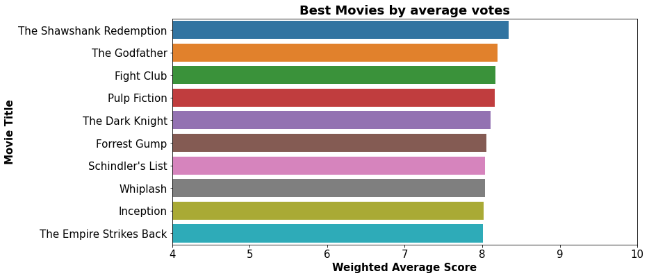

```python
# Import library
import matplotlib.pyplot as plt
import seaborn as sns

# Sorted dataset according the weighted averages, from highest to lowest
weight_average = movie_sorted_ranking.sort_values('weighted_average', ascending = False)

# Create barplot
plt.figure(figsize = (12,6))
axis1 = sns.barplot(x = weight_average['weighted_average'].head(10), y = weight_average['original_title'].head(10), data = weight_average)
plt.title('Best Movies by average votes', weight = 'bold')
plt.xlabel('Weighted Average Score', weight = 'bold')
plt.ylabel('Movie Title', weight = 'bold')
plt.xlim(4, 10)
plt.show()
```

```python
# Sorted dataset according to popularity
popularity = movie_sorted_ranking.sort_values('popularity',ascending = False)

# Check data
popularity.head()
```

|  | budget | genres | id | keywords | original_language | original_title | overview | popularity | production_companies | release_date | revenue | runtime | spoken_languages | tagline | vote_average | vote_count | cast | crew | weighted_average |
| --- | --- | --- | --- | --- | --- | --- | --- | --- | --- | --- | --- | --- | --- | --- | --- | --- | --- | --- | --- |
| 546 | 74000000 | [{"id": 10751, "name": "Family"}, {"id": 16, "... | 211672 | [{"id": 3487, "name": "assistant"}, {"id": 179... | en | Minions | Minions Stuart, Kevin and Bob are recruited by... | 875.581 | [{"name": "Universal Pictures", "id": 33}, {"n... | 2015-06-17 | 1156730962 | 91.000 | [{"iso_639_1": "en", "name": "English"}] | Before Gru, they had a history of bad bosses | 6.400 | 4571 | [{"cast_id": 22, "character": "Scarlet Overkil... | [{"credit_id": "5431b2b10e0a2656e20026c7", "de... | 6.365 |
| 95 | 165000000 | [{"id": 12, "name": "Adventure"}, {"id": 18, "... | 157336 | [{"id": 83, "name": "saving the world"}, {"id"... | en | Interstellar | Interstellar chronicles the adventures of a gr... | 724.248 | [{"name": "Paramount Pictures", "id": 4}, {"na... | 2014-11-05 | 675120017 | 169.000 | [{"iso_639_1": "en", "name": "English"}] | Mankind was born on Earth. It was never meant ... | 8.100 | 10867 | [{"cast_id": 9, "character": "Joseph Cooper", ... | [{"credit_id": "52fe4bbf9251416c910e4801", "de... | 7.998 |
| 788 | 58000000 | [{"id": 28, "name": "Action"}, {"id": 12, "nam... | 293660 | [{"id": 2095, "name": "anti hero"}, {"id": 307... | en | Deadpool | Deadpool tells the origin story of former Spec... | 514.570 | [{"name": "Twentieth Century Fox Film Corporat... | 2016-02-09 | 783112979 | 108.000 | [{"iso_639_1": "en", "name": "English"}] | Witness the beginning of a happy ending | 7.400 | 10995 | [{"cast_id": 99, "character": "Wade Wilson / D... | [{"credit_id": "56c986b2925141172f0068b6", "de... | 7.334 |
| 94 | 170000000 | [{"id": 28, "name": "Action"}, {"id": 878, "na... | 118340 | [{"id": 8828, "name": "marvel comic"}, {"id": ... | en | Guardians of the Galaxy | Light years from Earth, 26 years after being a... | 481.099 | [{"name": "Marvel Studios", "id": 420}, {"name... | 2014-07-30 | 773328629 | 121.000 | [{"iso_639_1": "en", "name": "English"}] | All heroes start somewhere. | 7.900 | 9742 | [{"cast_id": 1, "character": "Peter Quill / St... | [{"credit_id": "538ce329c3a3687155003358", "de... | 7.798 |
| 127 | 150000000 | [{"id": 28, "name": "Action"}, {"id": 12, "nam... | 76341 | [{"id": 2964, "name": "future"}, {"id": 3713, ... | en | Mad Max: Fury Road | An apocalyptic story set in the furthest reach... | 434.279 | [{"name": "Village Roadshow Pictures", "id": 7... | 2015-05-13 | 378858340 | 120.000 | [{"iso_639_1": "en", "name": "English"}] | What a Lovely Day. | 7.200 | 9427 | [{"cast_id": 2, "character": "Max Rockatansky"... | [{"credit_id": "577da370c3a36817f8003838", "de... | 7.136 |

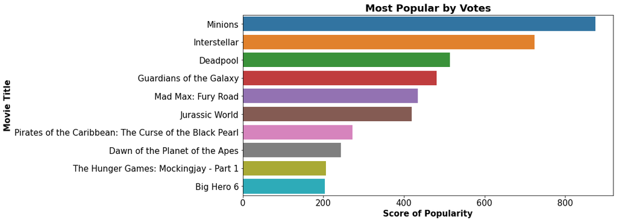

```python
# Create barplot
plt.figure(figsize = (12,6))
ax = sns.barplot(x = popularity['popularity'].head(10), y = popularity['original_title'].head(10), data = popularity)
plt.title('Most Popular by Votes', weight = 'bold')
plt.xlabel('Score of Popularity', weight = 'bold')
plt.ylabel('Movie Title', weight = 'bold')
```

### Data Scaling

```python
# Recommendation based on scaled weighted average and popularity score (Priority is given 50% to both)
# Import library
from sklearn.preprocessing import MinMaxScaler

# Scale the data
scaling = MinMaxScaler()
movie_scaled_df = scaling.fit_transform(movies_cleaned_df[['weighted_average','popularity']])

# Create dataframe
movie_normalized_df = pd.DataFrame(movie_scaled_df,columns = ['weighted_average','popularity'])

# Check data
movie_normalized_df.head()
```

|  | weighted_average | popularity |
| --- | --- | --- |
| 0 | 0.674 | 0.172 |
| 1 | 0.581 | 0.159 |
| 2 | 0.436 | 0.123 |
| 3 | 0.773 | 0.128 |
| 4 | 0.388 | 0.050 |

```python
# Insert new columns
movies_cleaned_df[['normalized_weight_average','normalized_popularity']]= movie_normalized_df
```

```python
# Check data
movies_cleaned_df.head()
```

|  | budget | genres | id | keywords | original_language | original_title | overview | popularity | production_companies | release_date | ... | runtime | spoken_languages | tagline | vote_average | vote_count | cast | crew | weighted_average | normalized_weight_average | normalized_popularity |
| --- | --- | --- | --- | --- | --- | --- | --- | --- | --- | --- | --- | --- | --- | --- | --- | --- | --- | --- | --- | --- | --- |
| 0 | 237000000 | [{"id": 28, "name": "Action"}, {"id": 12, "nam... | 19995 | [{"id": 1463, "name": "culture clash"}, {"id":... | en | Avatar | In the 22nd century, a paraplegic Marine is di... | 150.438 | [{"name": "Ingenious Film Partners", "id": 289... | 2009-12-10 | ... | 162.000 | [{"iso_639_1": "en", "name": "English"}, {"iso... | Enter the World of Pandora. | 7.200 | 11800 | [{"cast_id": 242, "character": "Jake Sully", "... | [{"credit_id": "52fe48009251416c750aca23", "de... | 7.148 | 0.674 | 0.172 |
| 1 | 300000000 | [{"id": 12, "name": "Adventure"}, {"id": 14, "... | 285 | [{"id": 270, "name": "ocean"}, {"id": 726, "na... | en | Pirates of the Caribbean: At World's End | Captain Barbossa, long believed to be dead, ha... | 139.083 | [{"name": "Walt Disney Pictures", "id": 2}, {"... | 2007-05-19 | ... | 169.000 | [{"iso_639_1": "en", "name": "English"}] | At the end of the world, the adventure begins. | 6.900 | 4500 | [{"cast_id": 4, "character": "Captain Jack Spa... | [{"credit_id": "52fe4232c3a36847f800b579", "de... | 6.808 | 0.581 | 0.159 |
| 2 | 245000000 | [{"id": 28, "name": "Action"}, {"id": 12, "nam... | 206647 | [{"id": 470, "name": "spy"}, {"id": 818, "name... | en | Spectre | A cryptic message from Bond’s past sends him o... | 107.377 | [{"name": "Columbia Pictures", "id": 5}, {"nam... | 2015-10-26 | ... | 148.000 | [{"iso_639_1": "fr", "name": "Fran\u00e7ais"},... | A Plan No One Escapes | 6.300 | 4466 | [{"cast_id": 1, "character": "James Bond", "cr... | [{"credit_id": "54805967c3a36829b5002c41", "de... | 6.276 | 0.436 | 0.123 |
| 3 | 250000000 | [{"id": 28, "name": "Action"}, {"id": 80, "nam... | 49026 | [{"id": 849, "name": "dc comics"}, {"id": 853,... | en | The Dark Knight Rises | Following the death of District Attorney Harve... | 112.313 | [{"name": "Legendary Pictures", "id": 923}, {"... | 2012-07-16 | ... | 165.000 | [{"iso_639_1": "en", "name": "English"}] | The Legend Ends | 7.600 | 9106 | [{"cast_id": 2, "character": "Bruce Wayne / Ba... | [{"credit_id": "52fe4781c3a36847f81398c3", "de... | 7.510 | 0.773 | 0.128 |
| 4 | 260000000 | [{"id": 28, "name": "Action"}, {"id": 12, "nam... | 49529 | [{"id": 818, "name": "based on novel"}, {"id":... | en | John Carter | John Carter is a war-weary, former military ca... | 43.927 | [{"name": "Walt Disney Pictures", "id": 2}] | 2012-03-07 | ... | 132.000 | [{"iso_639_1": "en", "name": "English"}] | Lost in our world, found in another. | 6.100 | 2124 | [{"cast_id": 5, "character": "John Carter", "c... | [{"credit_id": "52fe479ac3a36847f813eaa3", "de... | 6.098 | 0.388 | 0.050 |

5 rows × 21 columns

### Apply Weighted Average Formula

```python
# Create new column
movies_cleaned_df['score'] = (movies_cleaned_df['normalized_weight_average'] * 0.5) + (movies_cleaned_df['normalized_popularity'] * 0.5)

# Sort data according to score
movies_scored_df = movies_cleaned_df.sort_values(['score'], ascending = False)

# Check data
movies_scored_df[['original_title', 'normalized_weight_average', 'normalized_popularity', 'score']].head(20)
```

|  | original_title | normalized_weight_average | normalized_popularity | score |
| --- | --- | --- | --- | --- |
| 95 | Interstellar | 0.906 | 0.827 | 0.867 |
| 546 | Minions | 0.461 | 1.000 | 0.730 |
| 94 | Guardians of the Galaxy | 0.852 | 0.549 | 0.701 |
| 788 | Deadpool | 0.725 | 0.588 | 0.656 |
| 127 | Mad Max: Fury Road | 0.671 | 0.496 | 0.583 |
| 1881 | The Shawshank Redemption | 1.000 | 0.156 | 0.578 |
| 65 | The Dark Knight | 0.935 | 0.214 | 0.574 |
| 3865 | Whiplash | 0.916 | 0.220 | 0.568 |
| 3337 | The Godfather | 0.960 | 0.164 | 0.562 |
| 662 | Fight Club | 0.954 | 0.168 | 0.561 |
| 96 | Inception | 0.912 | 0.191 | 0.552 |
| 3232 | Pulp Fiction | 0.950 | 0.139 | 0.544 |
| 809 | Forrest Gump | 0.922 | 0.158 | 0.540 |
| 199 | Pirates of the Caribbean: The Curse of the Bla... | 0.741 | 0.311 | 0.526 |
| 2294 | 千と千尋の神隠し | 0.910 | 0.136 | 0.523 |
| 88 | Big Hero 6 | 0.812 | 0.233 | 0.522 |
| 329 | The Lord of the Rings: The Return of the King | 0.897 | 0.141 | 0.519 |
| 1818 | Schindler's List | 0.918 | 0.119 | 0.518 |
| 2912 | Star Wars | 0.890 | 0.144 | 0.517 |
| 262 | The Lord of the Rings: The Fellowship of the Ring | 0.874 | 0.158 | 0.516 |

### Result

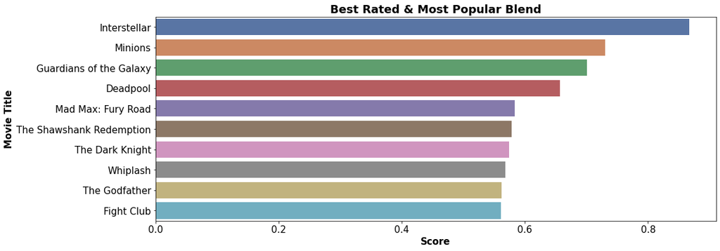

```python
# Sorted data
scored_df = movies_cleaned_df.sort_values('score', ascending = False)

# Create barplot
plt.figure(figsize=(16,6))
ax = sns.barplot(x=scored_df['score'].head(10), y = scored_df['original_title'].head(10), data=scored_df, palette='deep')
plt.title('Best Rated & Most Popular Blend', weight = 'bold')
plt.xlabel('Score', weight = 'bold')
plt.ylabel('Movie Title', weight = 'bold')
plt.show()
```

## Content-Based Filtering

[figure not shown]

### Import Libraries And Data

```python
# Import libraries
import pandas as pd
import numpy as np
```

```python
# Import datasets
movies_df = pd.read_csv("tmdb_5000_movies.csv")
credits = pd.read_csv("tmdb_5000_credits.csv")
```

### Data Exploration

```python
# Check movies data
movies_df.head()
```

|  | budget | genres | homepage | id | keywords | original_language | original_title | overview | popularity | production_companies | production_countries | release_date | revenue | runtime | spoken_languages | status | tagline | title | vote_average | vote_count |
| --- | --- | --- | --- | --- | --- | --- | --- | --- | --- | --- | --- | --- | --- | --- | --- | --- | --- | --- | --- | --- |
| 0 | 237000000 | [{"id": 28, "name": "Action"}, {"id": 12, "nam... | http://www.avatarmovie.com/ | 19995 | [{"id": 1463, "name": "culture clash"}, {"id":... | en | Avatar | In the 22nd century, a paraplegic Marine is di... | 150.437577 | [{"name": "Ingenious Film Partners", "id": 289... | [{"iso_3166_1": "US", "name": "United States o... | 2009-12-10 | 2787965087 | 162.0 | [{"iso_639_1": "en", "name": "English"}, {"iso... | Released | Enter the World of Pandora. | Avatar | 7.2 | 11800 |
| 1 | 300000000 | [{"id": 12, "name": "Adventure"}, {"id": 14, "... | http://disney.go.com/disneypictures/pirates/ | 285 | [{"id": 270, "name": "ocean"}, {"id": 726, "na... | en | Pirates of the Caribbean: At World's End | Captain Barbossa, long believed to be dead, ha... | 139.082615 | [{"name": "Walt Disney Pictures", "id": 2}, {"... | [{"iso_3166_1": "US", "name": "United States o... | 2007-05-19 | 961000000 | 169.0 | [{"iso_639_1": "en", "name": "English"}] | Released | At the end of the world, the adventure begins. | Pirates of the Caribbean: At World's End | 6.9 | 4500 |
| 2 | 245000000 | [{"id": 28, "name": "Action"}, {"id": 12, "nam... | http://www.sonypictures.com/movies/spectre/ | 206647 | [{"id": 470, "name": "spy"}, {"id": 818, "name... | en | Spectre | A cryptic message from Bond’s past sends him o... | 107.376788 | [{"name": "Columbia Pictures", "id": 5}, {"nam... | [{"iso_3166_1": "GB", "name": "United Kingdom"... | 2015-10-26 | 880674609 | 148.0 | [{"iso_639_1": "fr", "name": "Fran\u00e7ais"},... | Released | A Plan No One Escapes | Spectre | 6.3 | 4466 |
| 3 | 250000000 | [{"id": 28, "name": "Action"}, {"id": 80, "nam... | http://www.thedarkknightrises.com/ | 49026 | [{"id": 849, "name": "dc comics"}, {"id": 853,... | en | The Dark Knight Rises | Following the death of District Attorney Harve... | 112.312950 | [{"name": "Legendary Pictures", "id": 923}, {"... | [{"iso_3166_1": "US", "name": "United States o... | 2012-07-16 | 1084939099 | 165.0 | [{"iso_639_1": "en", "name": "English"}] | Released | The Legend Ends | The Dark Knight Rises | 7.6 | 9106 |
| 4 | 260000000 | [{"id": 28, "name": "Action"}, {"id": 12, "nam... | http://movies.disney.com/john-carter | 49529 | [{"id": 818, "name": "based on novel"}, {"id":... | en | John Carter | John Carter is a war-weary, former military ca... | 43.926995 | [{"name": "Walt Disney Pictures", "id": 2}] | [{"iso_3166_1": "US", "name": "United States o... | 2012-03-07 | 284139100 | 132.0 | [{"iso_639_1": "en", "name": "English"}] | Released | Lost in our world, found in another. | John Carter | 6.1 | 2124 |

```python
# Check credits data
credits.head()
```

|  | movie_id | title | cast | crew |
| --- | --- | --- | --- | --- |
| 0 | 19995 | Avatar | [{"cast_id": 242, "character": "Jake Sully", "... | [{"credit_id": "52fe48009251416c750aca23", "de... |
| 1 | 285 | Pirates of the Caribbean: At World's End | [{"cast_id": 4, "character": "Captain Jack Spa... | [{"credit_id": "52fe4232c3a36847f800b579", "de... |
| 2 | 206647 | Spectre | [{"cast_id": 1, "character": "James Bond", "cr... | [{"credit_id": "54805967c3a36829b5002c41", "de... |
| 3 | 49026 | The Dark Knight Rises | [{"cast_id": 2, "character": "Bruce Wayne / Ba... | [{"credit_id": "52fe4781c3a36847f81398c3", "de... |
| 4 | 49529 | John Carter | [{"cast_id": 5, "character": "John Carter", "c... | [{"credit_id": "52fe479ac3a36847f813eaa3", "de... |

```python
# Check datasets dimension
print("Credits:", credits.shape)
print("Movies:", movies_df.shape)
```

```
Credits: (4803, 4)
Movies: (4803, 20)
```

### Data Preprocessing

```python
# Rename column
credits_column_renamed = credits.rename(index = str, columns = {"movie_id": "id"})

# Merge column data
movies_df_merge = movies_df.merge(credits_column_renamed, on = 'id')

# Check data
movies_df_merge.head()
```

|  | budget | genres | homepage | id | keywords | original_language | original_title | overview | popularity | production_companies | ... | runtime | spoken_languages | status | tagline | title_x | vote_average | vote_count | title_y | cast | crew |
| --- | --- | --- | --- | --- | --- | --- | --- | --- | --- | --- | --- | --- | --- | --- | --- | --- | --- | --- | --- | --- | --- |
| 0 | 237000000 | [{"id": 28, "name": "Action"}, {"id": 12, "nam... | http://www.avatarmovie.com/ | 19995 | [{"id": 1463, "name": "culture clash"}, {"id":... | en | Avatar | In the 22nd century, a paraplegic Marine is di... | 150.437577 | [{"name": "Ingenious Film Partners", "id": 289... | ... | 162.0 | [{"iso_639_1": "en", "name": "English"}, {"iso... | Released | Enter the World of Pandora. | Avatar | 7.2 | 11800 | Avatar | [{"cast_id": 242, "character": "Jake Sully", "... | [{"credit_id": "52fe48009251416c750aca23", "de... |
| 1 | 300000000 | [{"id": 12, "name": "Adventure"}, {"id": 14, "... | http://disney.go.com/disneypictures/pirates/ | 285 | [{"id": 270, "name": "ocean"}, {"id": 726, "na... | en | Pirates of the Caribbean: At World's End | Captain Barbossa, long believed to be dead, ha... | 139.082615 | [{"name": "Walt Disney Pictures", "id": 2}, {"... | ... | 169.0 | [{"iso_639_1": "en", "name": "English"}] | Released | At the end of the world, the adventure begins. | Pirates of the Caribbean: At World's End | 6.9 | 4500 | Pirates of the Caribbean: At World's End | [{"cast_id": 4, "character": "Captain Jack Spa... | [{"credit_id": "52fe4232c3a36847f800b579", "de... |
| 2 | 245000000 | [{"id": 28, "name": "Action"}, {"id": 12, "nam... | http://www.sonypictures.com/movies/spectre/ | 206647 | [{"id": 470, "name": "spy"}, {"id": 818, "name... | en | Spectre | A cryptic message from Bond’s past sends him o... | 107.376788 | [{"name": "Columbia Pictures", "id": 5}, {"nam... | ... | 148.0 | [{"iso_639_1": "fr", "name": "Fran\u00e7ais"},... | Released | A Plan No One Escapes | Spectre | 6.3 | 4466 | Spectre | [{"cast_id": 1, "character": "James Bond", "cr... | [{"credit_id": "54805967c3a36829b5002c41", "de... |
| 3 | 250000000 | [{"id": 28, "name": "Action"}, {"id": 80, "nam... | http://www.thedarkknightrises.com/ | 49026 | [{"id": 849, "name": "dc comics"}, {"id": 853,... | en | The Dark Knight Rises | Following the death of District Attorney Harve... | 112.312950 | [{"name": "Legendary Pictures", "id": 923}, {"... | ... | 165.0 | [{"iso_639_1": "en", "name": "English"}] | Released | The Legend Ends | The Dark Knight Rises | 7.6 | 9106 | The Dark Knight Rises | [{"cast_id": 2, "character": "Bruce Wayne / Ba... | [{"credit_id": "52fe4781c3a36847f81398c3", "de... |
| 4 | 260000000 | [{"id": 28, "name": "Action"}, {"id": 12, "nam... | http://movies.disney.com/john-carter | 49529 | [{"id": 818, "name": "based on novel"}, {"id":... | en | John Carter | John Carter is a war-weary, former military ca... | 43.926995 | [{"name": "Walt Disney Pictures", "id": 2}] | ... | 132.0 | [{"iso_639_1": "en", "name": "English"}] | Released | Lost in our world, found in another. | John Carter | 6.1 | 2124 | John Carter | [{"cast_id": 5, "character": "John Carter", "c... | [{"credit_id": "52fe479ac3a36847f813eaa3", "de... |

5 rows × 23 columns

```python
# Drop unnecessary columns
movies_cleaned_df = movies_df_merge.drop(columns = ['homepage', 'title_x', 'title_y', 'status','production_countries'])

# Check data
movies_cleaned_df.head()
```

|  | budget | genres | id | keywords | original_language | original_title | overview | popularity | production_companies | release_date | revenue | runtime | spoken_languages | tagline | vote_average | vote_count | cast | crew |
| --- | --- | --- | --- | --- | --- | --- | --- | --- | --- | --- | --- | --- | --- | --- | --- | --- | --- | --- |
| 0 | 237000000 | [{"id": 28, "name": "Action"}, {"id": 12, "nam... | 19995 | [{"id": 1463, "name": "culture clash"}, {"id":... | en | Avatar | In the 22nd century, a paraplegic Marine is di... | 150.437577 | [{"name": "Ingenious Film Partners", "id": 289... | 2009-12-10 | 2787965087 | 162.0 | [{"iso_639_1": "en", "name": "English"}, {"iso... | Enter the World of Pandora. | 7.2 | 11800 | [{"cast_id": 242, "character": "Jake Sully", "... | [{"credit_id": "52fe48009251416c750aca23", "de... |
| 1 | 300000000 | [{"id": 12, "name": "Adventure"}, {"id": 14, "... | 285 | [{"id": 270, "name": "ocean"}, {"id": 726, "na... | en | Pirates of the Caribbean: At World's End | Captain Barbossa, long believed to be dead, ha... | 139.082615 | [{"name": "Walt Disney Pictures", "id": 2}, {"... | 2007-05-19 | 961000000 | 169.0 | [{"iso_639_1": "en", "name": "English"}] | At the end of the world, the adventure begins. | 6.9 | 4500 | [{"cast_id": 4, "character": "Captain Jack Spa... | [{"credit_id": "52fe4232c3a36847f800b579", "de... |
| 2 | 245000000 | [{"id": 28, "name": "Action"}, {"id": 12, "nam... | 206647 | [{"id": 470, "name": "spy"}, {"id": 818, "name... | en | Spectre | A cryptic message from Bond’s past sends him o... | 107.376788 | [{"name": "Columbia Pictures", "id": 5}, {"nam... | 2015-10-26 | 880674609 | 148.0 | [{"iso_639_1": "fr", "name": "Fran\u00e7ais"},... | A Plan No One Escapes | 6.3 | 4466 | [{"cast_id": 1, "character": "James Bond", "cr... | [{"credit_id": "54805967c3a36829b5002c41", "de... |
| 3 | 250000000 | [{"id": 28, "name": "Action"}, {"id": 80, "nam... | 49026 | [{"id": 849, "name": "dc comics"}, {"id": 853,... | en | The Dark Knight Rises | Following the death of District Attorney Harve... | 112.312950 | [{"name": "Legendary Pictures", "id": 923}, {"... | 2012-07-16 | 1084939099 | 165.0 | [{"iso_639_1": "en", "name": "English"}] | The Legend Ends | 7.6 | 9106 | [{"cast_id": 2, "character": "Bruce Wayne / Ba... | [{"credit_id": "52fe4781c3a36847f81398c3", "de... |
| 4 | 260000000 | [{"id": 28, "name": "Action"}, {"id": 12, "nam... | 49529 | [{"id": 818, "name": "based on novel"}, {"id":... | en | John Carter | John Carter is a war-weary, former military ca... | 43.926995 | [{"name": "Walt Disney Pictures", "id": 2}] | 2012-03-07 | 284139100 | 132.0 | [{"iso_639_1": "en", "name": "English"}] | Lost in our world, found in another. | 6.1 | 2124 | [{"cast_id": 5, "character": "John Carter", "c... | [{"credit_id": "52fe479ac3a36847f813eaa3", "de... |

```python
# Check data info
movies_cleaned_df.info()
```

```
<class 'pandas.core.frame.DataFrame'>
Int64Index: 4803 entries, 0 to 4802
Data columns (total 18 columns):
 #   Column                Non-Null Count  Dtype
---  ------                --------------  -----
 0   budget                4803 non-null   int64
 1   genres                4803 non-null   object
 2   id                    4803 non-null   int64
 3   keywords              4803 non-null   object
 4   original_language     4803 non-null   object
 5   original_title        4803 non-null   object
 6   overview              4800 non-null   object
 7   popularity            4803 non-null   float64
 8   production_companies  4803 non-null   object
 9   release_date          4802 non-null   object
 10  revenue               4803 non-null   int64
 11  runtime               4801 non-null   float64
 12  spoken_languages      4803 non-null   object
 13  tagline               3959 non-null   object
 14  vote_average          4803 non-null   float64
 15  vote_count            4803 non-null   int64
 16  cast                  4803 non-null   object
 17  crew                  4803 non-null   object
dtypes: float64(3), int64(4), object(11)
memory usage: 712.9+ KB
```

```python
# Check data
movies_cleaned_df.head(1)['overview']
```

```
0    In the 22nd century, a paraplegic Marine is di...
Name: overview, dtype: object
```

### Apply TF-IDF Vectorizer

```python
# Import library
from sklearn.feature_extraction.text import TfidfVectorizer

# Apply vectorizer
tfv = TfidfVectorizer(min_df = 3,  max_features = None,
            strip_accents = 'unicode', analyzer = 'word', token_pattern = r'\w{1,}', # Remove unncessary characters !@#$%^&*()
            ngram_range = (1, 3), # Take 1 to 3 combinations of words
            stop_words = 'english') # Remove unneccessary words

# Fill NaNs with empty string
movies_cleaned_df['overview'] = movies_cleaned_df['overview'].fillna('')
```

```python
# Fit the TF-IDF on the 'overview' text
tfv_matrix = tfv.fit_transform(movies_cleaned_df['overview'])

# Sparse matrix
tfv_matrix
```

```
<4803x10417 sparse matrix of type '<class 'numpy.float64'>'
	with 127220 stored elements in Compressed Sparse Row format>
```

```python
# Check data dimension
tfv_matrix.shape
```

```
(4803, 10417)
```

```python
# Import library
from sklearn.metrics.pairwise import sigmoid_kernel

# Compute the sigmoid kernel
sig = sigmoid_kernel(tfv_matrix, tfv_matrix)
```

```python
# Check data relation score
sig[0]
```

```
array([0.76163447, 0.76159416, 0.76159416, ..., 0.76159416, 0.76159416,
       0.76159416])
```

```python
# Reverse mapping of indices and movie titles
indices = pd.Series(movies_cleaned_df.index, index = movies_cleaned_df['original_title']).drop_duplicates()
```

```python
# Check data
indices
```

```
original_title
Avatar                                         0
Pirates of the Caribbean: At World's End       1
Spectre                                        2
The Dark Knight Rises                          3
John Carter                                    4
                                            ...
El Mariachi                                 4798
Newlyweds                                   4799
Signed, Sealed, Delivered                   4800
Shanghai Calling                            4801
My Date with Drew                           4802
Length: 4803, dtype: int64
```

```python
# Check data
indices['Newlyweds']
```

```
4799
```

```python
# Check data relation score
sig[4799]
```

```
array([0.76159416, 0.76159416, 0.76159438, ..., 0.76159432, 0.76159416,
       0.76159478])
```

```python
# Show 10 indices and its relation score
list(enumerate(sig[indices['Newlyweds']][:10]))
```

```
[(0, 0.7615941559557649),
 (1, 0.7615941559557649),
 (2, 0.7615943791623508),
 (3, 0.7615945564232902),
 (4, 0.7615945779342557),
 (5, 0.7615943267971559),
 (6, 0.7615948190414071),
 (7, 0.761594346971664),
 (8, 0.7615943903358866),
 (9, 0.761594688255891)]
```

```python
# Show indices and its relation score in descending order # Top 10
sorted(list(enumerate(sig[indices['Newlyweds']][:10])), key = lambda x: x[1], reverse = True)
```

```
[(6, 0.7615948190414071),
 (9, 0.761594688255891),
 (4, 0.7615945779342557),
 (3, 0.7615945564232902),
 (8, 0.7615943903358866),
 (2, 0.7615943791623508),
 (7, 0.761594346971664),
 (5, 0.7615943267971559),
 (0, 0.7615941559557649),
 (1, 0.7615941559557649)]
```

```python
# Recommender function
def give_rec(title, sig = sig):

    # Get the index corresponding to original_title
    idx = indices[title]

    # Get the pairwsie similarity scores
    sig_scores = list(enumerate(sig[idx]))

    # Sort the movies
    sig_scores = sorted(sig_scores, key = lambda x: x[1], reverse=True)

    # Scores of the 10 most similar movies
    sig_scores = sig_scores[1:11]

    # Movie indices
    movie_indices = [i[0] for i in sig_scores]

    # Top 10 most similar movies
    return movies_cleaned_df['original_title'].iloc[movie_indices]
```

### Result

```python
# Test content-based recommendation system with the seminal film The Dark Knight Rises
give_rec('The Dark Knight Rises')
```

```
299                              Batman Forever
65                              The Dark Knight
1359                                     Batman
428                              Batman Returns
2507                                  Slow Burn
119                               Batman Begins
1181                                        JFK
9            Batman v Superman: Dawn of Justice
3854    Batman: The Dark Knight Returns, Part 2
210                              Batman & Robin
Name: original_title, dtype: object
```

# Book Recommendation System

## Collaborative Filtering

[figure not shown]

### Import Libraries And Data

```python
# Import libraries
import pandas as pd
import numpy as np
import matplotlib.pyplot as plt
```

```python
# Import data
books = pd.read_csv('BX-Books.csv', sep = ';', error_bad_lines = False, encoding = "latin-1")
users = pd.read_csv('BX-Users.csv', sep = ';', error_bad_lines = False, encoding = "latin-1")
ratings = pd.read_csv('BX-Book-Ratings.csv', sep = ';', error_bad_lines = False, encoding = "latin-1")
```

[output not shown]

```python
# Books columns
books.columns = ['ISBN', 'bookTitle', 'bookAuthor', 'yearOfPublication', 'publisher', 'imageUrlS', 'imageUrlM', 'imageUrlL']

# Users columns
users.columns = ['userID', 'Location', 'Age']

# Ratings columns
ratings.columns = ['userID', 'ISBN', 'bookRating']
```

```python
# Check dataset dimnensions
books.shape, users.shape, ratings.shape
```

```
((271360, 8), (278858, 3), (1149780, 3))
```

### Data Visualization

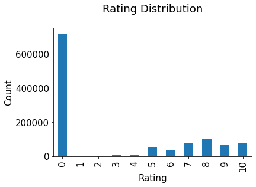

```python
# Create bar plot for ratings distribution
plt.rc("font", size=15)
ratings['bookRating'].value_counts(sort = False).plot(kind ='bar')
plt.title('Rating Distribution\n')
plt.xlabel('Rating')
plt.ylabel('Count')
plt.savefig('system1.png', bbox_inches='tight')
plt.show()
```

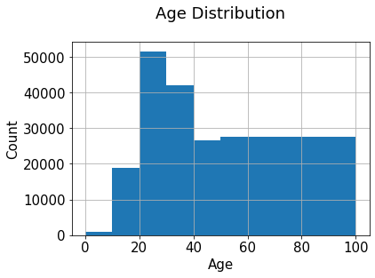

```python
# Create bar plot for age distribution
users['Age'].hist(bins=[0, 10, 20, 30, 40, 50, 100])
plt.title('Age Distribution\n')
plt.xlabel('Age')
plt.ylabel('Count')
plt.savefig('system2.png', bbox_inches='tight')
plt.show()
```

### Data Preprocessing

```python
# Get value counts
counts1 = ratings['userID'].value_counts()

# Get value counts
counts = ratings['bookRating'].value_counts()

# To ensure statistical significance, users with less than 200 ratings, and books with less than 100 ratings are excluded.
ratings = ratings[ratings['userID'].isin(counts1[counts1 >= 200].index)]
ratings = ratings[ratings['bookRating'].isin(counts[counts >= 100].index)]
```

```python
# KNN is a machine learning algorithm to find clusters of similar users based on common book ratings,
# and make predictions using the average rating of top-k nearest neighbors.
# For example, we first present ratings in a matrix with the matrix having one row for each item (book)
# and one column for each user.

# Merge data based on ISBN
combine_book_rating = pd.merge(ratings, books, on = 'ISBN')

# Data columns to be drop
columns = ['yearOfPublication', 'publisher', 'bookAuthor', 'imageUrlS', 'imageUrlM', 'imageUrlL']

# Drop columns
combine_book_rating = combine_book_rating.drop(columns, axis = 1)

# Check data
combine_book_rating.head()
```

|  | userID | ISBN | bookRating | bookTitle |
| --- | --- | --- | --- | --- |
| 0 | 277427 | 002542730X | 10 | Politically Correct Bedtime Stories: Modern Ta... |
| 1 | 3363 | 002542730X | 0 | Politically Correct Bedtime Stories: Modern Ta... |
| 2 | 11676 | 002542730X | 6 | Politically Correct Bedtime Stories: Modern Ta... |
| 3 | 12538 | 002542730X | 10 | Politically Correct Bedtime Stories: Modern Ta... |
| 4 | 13552 | 002542730X | 0 | Politically Correct Bedtime Stories: Modern Ta... |

```python
# Drop missing values
combine_book_rating = combine_book_rating.dropna(axis = 0, subset = ['bookTitle'])

# Group by book titles and create a new column for total rating count.
book_ratingCount = (combine_book_rating.
                    groupby(by = ['bookTitle'])['bookRating'].
                    count().
                    reset_index().
                    rename(columns = {'bookRating': 'totalRatingCount'})
                    [['bookTitle', 'totalRatingCount']]
                    )

# Check data
book_ratingCount.head()
```

|  | bookTitle | totalRatingCount |
| --- | --- | --- |
| 0 | A Light in the Storm: The Civil War Diary of ... | 2 |
| 1 | Always Have Popsicles | 1 |
| 2 | Apple Magic (The Collector's series) | 1 |
| 3 | Beyond IBM: Leadership Marketing and Finance ... | 1 |
| 4 | Clifford Visita El Hospital (Clifford El Gran... | 1 |

```python
# Combine the rating data with the total rating count data
# This gives exactly what we need to find out which books are popular and filter out lesser-known books
rating_with_totalRatingCount = combine_book_rating.merge(book_ratingCount, left_on = 'bookTitle', right_on = 'bookTitle', how = 'left')

# Check data
rating_with_totalRatingCount.head()
```

|  | userID | ISBN | bookRating | bookTitle | totalRatingCount |
| --- | --- | --- | --- | --- | --- |
| 0 | 277427 | 002542730X | 10 | Politically Correct Bedtime Stories: Modern Ta... | 82 |
| 1 | 3363 | 002542730X | 0 | Politically Correct Bedtime Stories: Modern Ta... | 82 |
| 2 | 11676 | 002542730X | 6 | Politically Correct Bedtime Stories: Modern Ta... | 82 |
| 3 | 12538 | 002542730X | 10 | Politically Correct Bedtime Stories: Modern Ta... | 82 |
| 4 | 13552 | 002542730X | 0 | Politically Correct Bedtime Stories: Modern Ta... | 82 |

```python
# Set decimal
pd.set_option('display.float_format', lambda x: '%.3f' % x)

# Check data statistics
print(book_ratingCount['totalRatingCount'].describe())
```

```
count   160576.000
mean         3.044
std          7.428
min          1.000
25%          1.000
50%          1.000
75%          2.000
max        365.000
Name: totalRatingCount, dtype: float64
```

```python
# The median book has been rated only once. Let’s look at the top of the distribution
print(book_ratingCount['totalRatingCount'].quantile(np.arange(.9, 1, .01)))
```

```
0.900    5.000
0.910    6.000
0.920    7.000
0.930    7.000
0.940    8.000
0.950   10.000
0.960   11.000
0.970   14.000
0.980   19.000
0.990   31.000
Name: totalRatingCount, dtype: float64
```

```python
# Set threshold
popularity_threshold = 50

# Satisfy threshold
rating_popular_book = rating_with_totalRatingCount.query('totalRatingCount >= @popularity_threshold')

# Check data
rating_popular_book.head()
```

|  | userID | ISBN | bookRating | bookTitle | totalRatingCount |
| --- | --- | --- | --- | --- | --- |
| 0 | 277427 | 002542730X | 10 | Politically Correct Bedtime Stories: Modern Ta... | 82 |
| 1 | 3363 | 002542730X | 0 | Politically Correct Bedtime Stories: Modern Ta... | 82 |
| 2 | 11676 | 002542730X | 6 | Politically Correct Bedtime Stories: Modern Ta... | 82 |
| 3 | 12538 | 002542730X | 10 | Politically Correct Bedtime Stories: Modern Ta... | 82 |
| 4 | 13552 | 002542730X | 0 | Politically Correct Bedtime Stories: Modern Ta... | 82 |

```python
# Check data dimension
rating_popular_book.shape
```

```
(62149, 5)
```

```python
# Merge column data
combined = rating_popular_book.merge(users, left_on = 'userID', right_on = 'userID', how = 'left')

# Filter to users in US and Canada only
us_canada_user_rating = combined[combined['Location'].str.contains("usa|canada")]

# Drop column
us_canada_user_rating = us_canada_user_rating.drop('Age', axis=1)

# Check data
us_canada_user_rating.head()
```

|  | userID | ISBN | bookRating | bookTitle | totalRatingCount | Location |
| --- | --- | --- | --- | --- | --- | --- |
| 0 | 277427 | 002542730X | 10 | Politically Correct Bedtime Stories: Modern Ta... | 82 | gilbert, arizona, usa |
| 1 | 3363 | 002542730X | 0 | Politically Correct Bedtime Stories: Modern Ta... | 82 | knoxville, tennessee, usa |
| 3 | 12538 | 002542730X | 10 | Politically Correct Bedtime Stories: Modern Ta... | 82 | byron, minnesota, usa |
| 4 | 13552 | 002542730X | 0 | Politically Correct Bedtime Stories: Modern Ta... | 82 | cordova, tennessee, usa |
| 5 | 16795 | 002542730X | 0 | Politically Correct Bedtime Stories: Modern Ta... | 82 | mechanicsville, maryland, usa |

```python
# Import library
from scipy.sparse import csr_matrix

# Drop duplicates
us_canada_user_rating = us_canada_user_rating.drop_duplicates(['userID', 'bookTitle'])

# Pivot dataframe
us_canada_user_rating_pivot = us_canada_user_rating.pivot(index = 'bookTitle', columns = 'userID', values = 'bookRating').fillna(0)

# Create sparse matrix
us_canada_user_rating_matrix = csr_matrix(us_canada_user_rating_pivot.values)
```

```python
# Check dataframe
us_canada_user_rating_pivot
```

| userID bookTitle | 254 | 2276 | 2766 | 2977 | 3363 | 4017 | 4385 | 6242 | 6251 | 6323 | ... | 271448 | 271705 | 273979 | 274061 | 274308 | 274808 | 275970 | 277427 | 277639 | 278418 |
| --- | --- | --- | --- | --- | --- | --- | --- | --- | --- | --- | --- | --- | --- | --- | --- | --- | --- | --- | --- | --- | --- |
| 1984 | 9.000 | 0.000 | 0.000 | 0.000 | 0.000 | 0.000 | 0.000 | 0.000 | 0.000 | 0.000 | ... | 0.000 | 10.000 | 0.000 | 0.000 | 0.000 | 0.000 | 0.000 | 0.000 | 0.000 | 0.000 |
| 1st to Die: A Novel | 0.000 | 0.000 | 0.000 | 0.000 | 0.000 | 0.000 | 0.000 | 0.000 | 0.000 | 0.000 | ... | 0.000 | 0.000 | 0.000 | 0.000 | 0.000 | 0.000 | 0.000 | 0.000 | 0.000 | 0.000 |
| 2nd Chance | 0.000 | 10.000 | 0.000 | 0.000 | 0.000 | 0.000 | 0.000 | 0.000 | 0.000 | 0.000 | ... | 0.000 | 0.000 | 0.000 | 0.000 | 0.000 | 0.000 | 0.000 | 0.000 | 0.000 | 0.000 |
| 4 Blondes | 0.000 | 0.000 | 0.000 | 0.000 | 0.000 | 0.000 | 0.000 | 0.000 | 0.000 | 0.000 | ... | 0.000 | 0.000 | 0.000 | 0.000 | 0.000 | 0.000 | 0.000 | 0.000 | 0.000 | 0.000 |
| 84 Charing Cross Road | 0.000 | 0.000 | 0.000 | 0.000 | 0.000 | 0.000 | 0.000 | 0.000 | 0.000 | 0.000 | ... | 0.000 | 0.000 | 0.000 | 0.000 | 0.000 | 0.000 | 10.000 | 0.000 | 0.000 | 0.000 |
| ... | ... | ... | ... | ... | ... | ... | ... | ... | ... | ... | ... | ... | ... | ... | ... | ... | ... | ... | ... | ... | ... |
| Year of Wonders | 0.000 | 0.000 | 0.000 | 7.000 | 0.000 | 0.000 | 0.000 | 7.000 | 0.000 | 0.000 | ... | 0.000 | 0.000 | 9.000 | 0.000 | 0.000 | 0.000 | 0.000 | 0.000 | 0.000 | 0.000 |
| You Belong To Me | 0.000 | 0.000 | 0.000 | 0.000 | 0.000 | 0.000 | 0.000 | 0.000 | 0.000 | 0.000 | ... | 0.000 | 0.000 | 0.000 | 0.000 | 0.000 | 0.000 | 0.000 | 0.000 | 0.000 | 0.000 |
| Zen and the Art of Motorcycle Maintenance: An Inquiry into Values | 0.000 | 0.000 | 0.000 | 0.000 | 0.000 | 0.000 | 0.000 | 0.000 | 0.000 | 0.000 | ... | 0.000 | 0.000 | 0.000 | 0.000 | 0.000 | 0.000 | 0.000 | 0.000 | 0.000 | 0.000 |
| Zoya | 0.000 | 0.000 | 0.000 | 0.000 | 0.000 | 0.000 | 0.000 | 0.000 | 0.000 | 0.000 | ... | 0.000 | 0.000 | 0.000 | 0.000 | 0.000 | 0.000 | 0.000 | 0.000 | 0.000 | 0.000 |
| \O\" Is for Outlaw" | 0.000 | 0.000 | 0.000 | 0.000 | 0.000 | 0.000 | 0.000 | 0.000 | 0.000 | 0.000 | ... | 0.000 | 0.000 | 0.000 | 0.000 | 0.000 | 0.000 | 0.000 | 0.000 | 0.000 | 0.000 |

746 rows × 734 columns

### Apply K-NN (Cosine Similarity)

```python
# Import library
from sklearn.neighbors import NearestNeighbors

# Cosine similarity
model_knn = NearestNeighbors(metric = 'cosine', algorithm = 'brute')

# Fit the model
model_knn.fit(us_canada_user_rating_matrix)
```

```
NearestNeighbors(algorithm='brute', metric='cosine')
```

```python
# Get a random sample
query_index = np.random.choice(us_canada_user_rating_pivot.shape[0])

# Show random sample
print('Index:', query_index, '=> Book:', us_canada_user_rating_pivot.index[query_index])

# Set distances and indices
distances, indices = model_knn.kneighbors(us_canada_user_rating_pivot.iloc[query_index,:].values.reshape(1, -1), n_neighbors = 6)
```

```
Index: 353 => Book: Mother of Pearl
```

### Result

```python
# Recommendation function
for i in range(0, len(distances.flatten())):
    if i == 0:
        print('Recommendations for {0}:\n'.format(us_canada_user_rating_pivot.index[query_index]))
    else:
        print('{0}: {1}, with distance of {2}:'.format(i, us_canada_user_rating_pivot.index[indices.flatten()[i]], distances.flatten()[i]))
```

```
Recommendations for Mother of Pearl:

1: River, Cross My Heart, with distance of 0.6940202225362795:
2: Song of Solomon (Oprah's Book Club (Paperback)), with distance of 0.7215526286784837:
3: Watermelon, with distance of 0.7599137034779938:
4: We Were the Mulvaneys, with distance of 0.7752395067391988:
5: A Patchwork Planet, with distance of 0.7926458891181571:
```